# Porównanie dwóch modeli

Szymon Dyrcz

2023-12-09

### Opis danych

Pierwszy zestaw danych zawiera dzienną przepływowość (Gauged Daily Flow) rzeki mierzoną na tej stacji. Dane te są przechowywane w bazie danych UK National River Flow Archive (nrfa-public-13) i obejmują okres od 1 października 1947 r. do 30 września 2018 r. Wskaźnik przepływu jest mierzony w metrach sześciennych na sekundę (m³/s).

Drugi zestaw danych zawiera dzienną ilość opadów atmosferycznych (Catchment Daily Rainfall) dla tej samej stacji. Dane te również są przechowywane w bazie danych UK National River Flow Archive (nrfa-public-13) i obejmują okres od 1 stycznia 1947 r. do 31 grudnia 2017 r. Ilość opadów jest mierzona w milimetrach (mm).

Oba zestawy danych są związane z tą samą stacją, która jest opisana jako stacja pomiaru prędkości na 80-metrowym odcinku rzeki. Stacja ta jest wpływana przez transfery z sąsiednich zlewni i elektrowni.

### Cel badania

Celem Case Study jest zaplikowanie modelu do wylosowanego modelu i danych.

### Co to ANOVA?

Model ANOVA (Analiza Wariacji) to technika statystyczna używana do porównywania średnich z trzech lub więcej grup. Testuje hipotezę, że średnie wszystkich grup są równe, a różnice między nimi są przypadkowe. Jeśli wynik testu ANOVA jest istotny, oznacza to, że przynajmniej jedna grupa różni się od innych.

### Uzasadnienie odrzucenia ANOVA

Analiza modelu losowego może nie być adekwatna do charakteru zgromadzonych danych. W kontekście informacji o przepływie wody oraz opadach atmosferycznych w wieloletnim okresie czasowym w Conon at Moy Bridge. Istnieje kilka powodów, dla których model ANOVA może być niewystarczający do analizy tych danych: Zmienna czasowa: Modele ANOVA nie uwzględniają zmiennych czasowych ani struktury sekwencyjnej danych, co jest kluczowe w przypadku analizy szeregów czasowych. Szeregi czasowe charakteryzują się zależnościami czasowymi i trendami, których nie można w pełni uwzględnić za pomocą ANOVA. Brak uwzględnienia sekwencji: Model ANOVA zakłada niezależność obserwacji, co może nie być prawdziwe w przypadku danych szeregów czasowych, gdzie pomiary w kolejnych okresach czasowych są ze sobą powiązane. Uwzględnienie dynamiki czasowej: Modele ANOVA nie są w stanie uchwycić zmian w czasie ani prognozować przyszłych wartości, co jest istotne w analizie szeregów czasowych, takich jak te dotyczące przepływu wody czy opadów atmosferycznych. Planuję zastosować modele naiwny oraz regresji liniowej, aby dokładniej zbadać i porównać ze sobą zebrane dane.

### Uzasadnienie wyboru modelu naiwnego

Model naiwny jest niezwykle prosty. W przypadku, gdy brak jest złożonych zależności między opadami a przepływem rzeki, prosty model może być wystarczający. Model naiwny jest łatwy do zrozumienia i interpretacji.

### Czym jest regresja liniowa i model naiwny?

Regresja liniowa to metoda statystyczna, która próbuje modelować zależność między zmienną zależną (odpowiedzią) a jedną lub więcej zmiennymi niezależnymi (predyktorami) za pomocą liniowej funkcji.

Model naiwny w kontekście analizy szeregów czasowych to model prognozowania, który zakłada, że przyszłe wartości szeregu czasowego będą równe ostatniej obserwowanej wartości. Jest często używany jako punkt odniesienia dla innych modeli do oceny ich wydajności.

### Wczytanie bibliotek

```r
library(zoo)
library(dplyr)
```

```r
library(ggplot2)
library(forecast)
```

### Ustawianie seedu

```r
set.seed(123)
```

## Preprocessing Danych

Dostarczone dane zawieraja brakujace wartosci z czym zostały poddane preprocessingowi.

### Wczytywanie danych i porządkowanie

```r
daily_rain <- read.csv("C:/Users/szymo/Downloads/daily_rain_4001_cdr.csv", skip=19)
river_flow <- read.csv("C:/Users/szymo/Downloads/river_flow1947_2018_4001_gdf.csv", skip = 19)
head(river_flow, 10)
```

```
##          data  last X2018.09.30
## 1  1947-10-01 62.30
## 2  1947-10-02 84.96
## 3  1947-10-03 56.64
## 4  1947-10-04 39.65
## 5  1947-10-05 28.32
## 6  1947-10-06 25.49
## 7  1947-10-07 22.66
## 8  1947-10-08 19.82
## 9  1947-10-09 25.49
## 10 1947-10-10 31.15
```

```r
head(daily_rain, 10)
```

```
##          data last X2017.12.31
## 1  1947-01-01  9.0       45000
## 2  1947-01-02  1.9       45000
## 3  1947-01-03 10.3       45000
## 4  1947-01-04  5.7       45000
## 5  1947-01-05  0.2       45000
## 6  1947-01-06  0.1       45000
## 7  1947-01-07  0.2       45000
## 8  1947-01-08  7.9       45000
## 9  1947-01-09  3.5       45000
## 10 1947-01-10  3.7       45000
```

```r
daily_rain <- daily_rain[, -ncol(daily_rain)]
river_flow <- river_flow[, -ncol(river_flow)]
summary(daily_rain)
```

```
##      data                last
##  Length:25933       Min.   :  0.000
##  Class :character   1st Qu.:  0.200
##  Mode  :character   Median :  2.100
##                     Mean   :  4.984
##                     3rd Qu.:  6.800
##                     Max.   :125.800
```

### Odfiltrowanie dat od 1947-10-01 bo to minimum w river flow

```r
daily_rain$data <- as.Date(daily_rain$data , format = "%Y-%m-%d")
```

### Odfiltrowanie danych, wybierając daty od 1947-10-01 do najnowszych

```r
filtered_data_rain <- daily_rain %>%
  filter(data >= as.Date("1947-10-01"))
```

### Identycznie z river flow, do 2017-12-31 bo to max daily rain

```r
river_flow$data <- as.Date(river_flow$data , format = "%Y-%m-%d")
```

### Odfiltrowanie danych, wybierając daty < 2017-12-31

```r
filtered_data_river <- river_flow %>%
  filter(data <= as.Date("2017-12-31"))
```

### Badanie braków danych w river

```r
any(is.na(filtered_data_river$last) | is.nan(filtered_data_river$last))
```

```
## [1] TRUE
```

### Wystapily braki danych (true)

```r
total_missing <- sum(is.na(filtered_data_river$last) | is.nan(filtered_data_river$last), na.rm = TRUE)
total_missing
```

```
## [1] 2041
```

### 2041 brakow danych

### Badanie braków danych w rain

```r
any(is.na(filtered_data_rain$last) | is.nan(filtered_data_rain$last))
```

```
## [1] FALSE
```

### Brak braku danych (false)

### Usuwanie braku danych dla długich przedziałów czasowych, gdzie nie było pomiarów

Usuwanie braku danych dla długich przedziałow, gdzie nie mieliśmy danych jest najlepszą opcją, ponieważ ciężko jest przewidzieć prawidłowo taki okres danych.

```r
filtered_data_river <- filtered_data_river %>%
  filter(!(data >= as.Date("1970-10-01") & data <= as.Date("1975-12-31")) &
           !(data >= as.Date("1958-05-01") & data <= as.Date("1958-05-31")) &
           !(data >= as.Date("1955-04-01") & data <= as.Date("1955-06-30")))

filtered_data_rain <- filtered_data_rain %>%
  filter(!(data >= as.Date("1970-10-01") & data <= as.Date("1975-12-31")) &
           !(data >= as.Date("1958-05-01") & data <= as.Date("1958-05-31")) &
           !(data >= as.Date("1955-04-01") & data <= as.Date("1955-06-30")))
```

### Interpolowanie wartosci dla konkretnej daty

```r
interpolated_value <- na.approx(filtered_data_river$last, x = filtered_data_river$data, xout = as.Date("1949-12-20"))
```

### Aktualizacja wartości dla konkretnej daty “1949-12-20” w kolumnie “last”

```r
filtered_data_river[filtered_data_river$date == as.Date("1949-12-20"), "last"] <- interpolated_value
```

### Zmiana nazw kolumn przed mergem

```r
filtered_data_river <- filtered_data_river %>% rename(river_flow = last)
filtered_data_rain <- filtered_data_rain %>% rename(rain = last)
```

### Mergowanie w jedne dane

```r
merged_df <- merge(filtered_data_river, filtered_data_rain, by = "data", all = TRUE)
```

## Korelacje

```r
coefficient <- cor.test(merged_df$river_flow, merged_df$rain)
coefficient$estimate
```

```
##       cor
## 0.4233146
```

### korelacja -> 0.4233146

### Wnioski

Wnioski z analizy tego modelu mogą obejmować to, że opady deszczu wydają się mieć istotny wpływ na przepływ rzeki, ale wciąż jest to tylko jeden z wielu czynników wpływających na tę zmienną. Model może mieć ograniczenia, a istnienie innych zmiennych mogących wpływać na przepływ rzeki może być powodem niskiego współczynnika determinacji. Może być konieczne uwzględnienie dodatkowych zmiennych w modelu, aby lepiej wyjaśnić zmienność w przepływie rzeki.

## Dzielenie zbioru danych na testowy i treningowy

### Tworzenie indeksu losowego dla podziału danych 80% danych do treningu

```r
indexes <- sample(nrow(merged_df), size = 0.8 * nrow(merged_df))
```

### Tworzenie zbioru treningowego i testowego na podstawie indeksów

```r
train_data <- merged_df[indexes, ]
test_data <- merged_df[-indexes, ]
```

### regresja liniowa

```r
linear_r <- lm(river_flow ~ rain, data = train_data)
summary(linear_r)
```

```
##
## Call:
## lm(formula = river_flow ~ rain, data = train_data)
##
## Residuals:
##     Min      1Q  Median      3Q     Max
## -287.52  -24.25   -6.36   16.51  731.16
##
## Coefficients:
##             Estimate Std. Error t value Pr(>|t|)
## (Intercept) 39.11737    0.31522  124.10   <2e-16 ***
## rain         2.25147    0.03547   63.47   <2e-16 ***
## ---
## Signif. codes:  0 '***' 0.001 '**' 0.01 '*' 0.05 '.' 0.1 ' ' 1
##
## Residual standard error: 35.64 on 18893 degrees of freedom
##   (1 obserwacja została skasowana z uwagi na braki w niej zawarte)
## Multiple R-squared:  0.1758, Adjusted R-squared:  0.1757
## F-statistic:  4029 on 1 and 18893 DF,  p-value: < 2.2e-16
```

```r
summary(linear_r)$r.squared
```

```
## [1] 0.1757694
```

### 0.175 is explained by the model (values) p-value jest znikome

Adjusted R-squared wynoszący 0.1757 sugeruje, że model wyjaśnia około 17.57% zmienności w danych. Wartość statystyki F wynosząca 4029 na 1 stopień swobody modelu i 18893 stopnie swobody błędu wskazuje na istotność modelu. Bardzo mała wartość p (mniejsza niż 2.2e-16) oznacza, że istnieje bardzo małe prawdopodobieństwo, że obserwowane dane mogłyby wystąpić, gdyby prawdziwa hipoteza zerowa była prawdziwa, co sugeruje, że model jest statystycznie istotny.

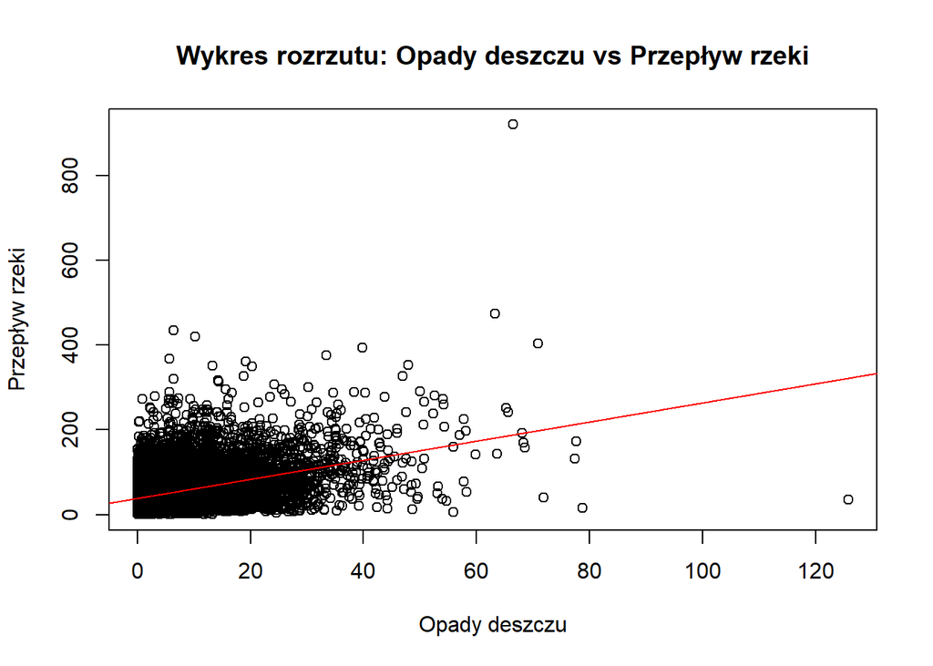

```r
plot(train_data$rain, train_data$river_flow,
     xlab = "Opady deszczu", ylab = "Przepływ rzeki",
     main = "Wykres rozrzutu: Opady deszczu vs Przepływ rzeki")

abline(lm(river_flow ~ rain, data = train_data), col = "red")
```

## Predykcja na zbiorze testowym

### 4 losowe wartosci dla zbioru testowego

```r
random_indices <- sample(1:nrow(test_data), 4)
random_test_data <- test_data[random_indices, ]
predictions <- predict(linear_r, newdata = random_test_data)
```

### Plot z porownywaniem wartosci losowych wybranych ze zbioru testowego (4) z predykcja(4)

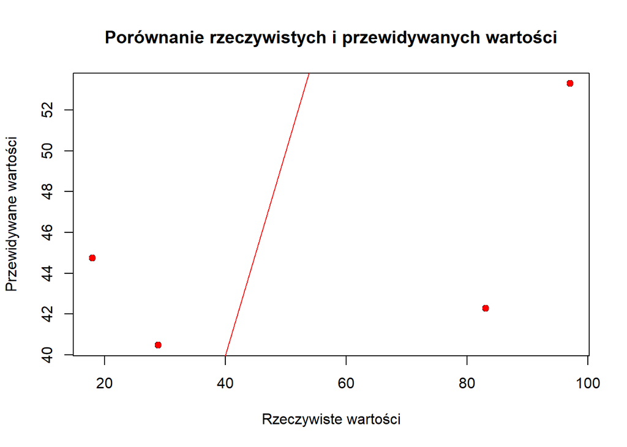

```r
plot(random_test_data$river_flow, predictions,
     xlab = "Rzeczywiste wartości", ylab = "Przewidywane wartości",
     main = "Porównanie rzeczywistych i przewidywanych wartości")
points(random_test_data$river_flow, predictions, col = "red", pch = 16)
abline(a = 0, b = 1, col = "red")
```

### Obliczanie reszt

```r
residuals <- random_test_data$river_flow - predictions
residuals
```

```
##      7966      2374     16355      7546
##  40.81057 -11.58825  43.78838 -26.79604
```

### Wykres reszt

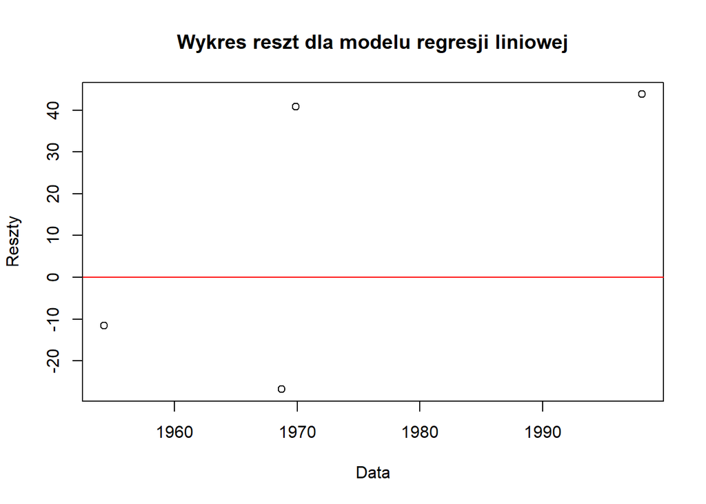

```r
plot(random_test_data$data, residuals,
     xlab = "Data", ylab = "Reszty",
     main = "Wykres reszt dla modelu regresji liniowej")
abline(h = 0, col = "red")
```

### Wniosek

Reszty odbiegają od 0, do ktorego powinny zmierzać

Model regresji liniowej sprawdza się najlepiej, gdy zmienna zależna (w tym przypadku przepływ rzeki) jest liniowo związana ze zmienną niezależną (opady deszczu).

## Model naiwny

```r
naive_model <- naive(train_data$river_flow)
```

## Predykcja na zbiorze testowym

```r
naive_predictions <- forecast(naive_model, h = length(random_test_data$river_flow))$mean
```

### Wykres porównawczy dla modelu naiwnego

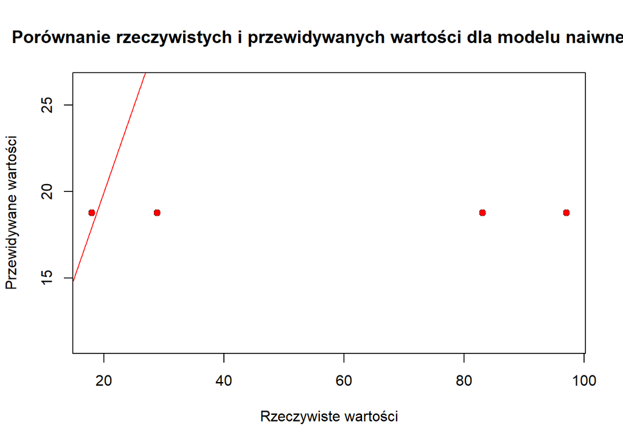

```r
plot(random_test_data$river_flow, naive_predictions,
     xlab = "Rzeczywiste wartości", ylab = "Przewidywane wartości",
     main = "Porównanie rzeczywistych i przewidywanych wartości dla modelu naiwnego")
points(random_test_data$river_flow, naive_predictions, col = "red", pch = 16)
abline(a = 0, b = 1, col = "red")
```

### Wykres porównujący modele z wartościami rzeczywistymi

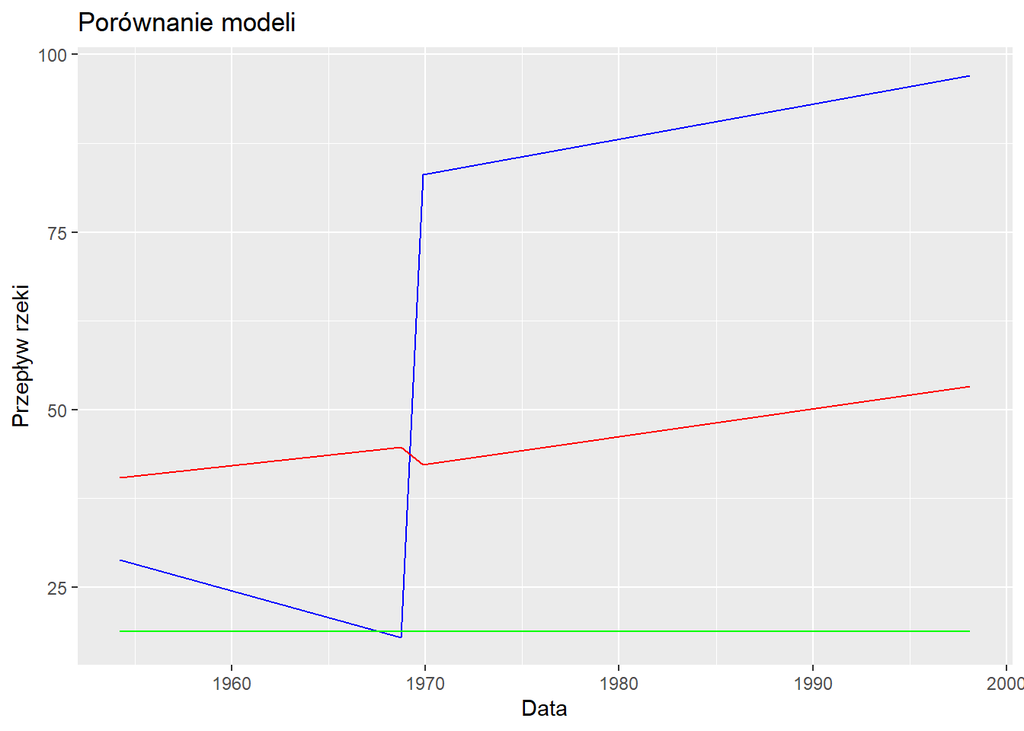

```r
ggplot() +
  geom_line(aes(x = random_test_data$data, y = random_test_data$river_flow), color = "blue") +
  geom_line(aes(x = random_test_data$data, y = predict(linear_r, newdata = random_test_data)), color = "red") +
  geom_line(aes(x = random_test_data$data, y = forecast(naive_model, h = length(random_test_data$river_flow))$mean), color = "green") +
  labs(title = "Porównanie modeli", x = "Data", y = "Przepływ rzeki")
```

### Obliczanie metryk błędów dla modelu regresji liniowej

```r
linear_rmse <- sqrt(mean((random_test_data$river_flow - predictions)^2))
linear_mae <- mean(abs(random_test_data$river_flow - predictions))
linear_mape <- mean(abs((random_test_data$river_flow - predictions) / random_test_data$river_flow)) * 100
```

### Obliczanie metryk błędów dla modelu naiwnego

```r
naive_rmse <- sqrt(mean((random_test_data$river_flow - naive_predictions)^2))
naive_mae <- mean(abs(random_test_data$river_flow - naive_predictions))
naive_mape <- mean(abs((random_test_data$river_flow - naive_predictions) / random_test_data$river_flow)) * 100
```

## Podsumowanie

Biorąc pod uwagę wszystkie trzy miary: